# Homework 5

## Section B: Plots

In this section, the code chunks are not created for you. Create a new code chunk below each problem and before the next to put your code for that problem. If the problem asks you questions that you should answer in words instead of code, write your answers in text below the problem rather than as comments in the code.

1. Plot per-capita GDP versus life expectancy for Colombia as a line, points, or both. Give the plot appropriate axis labels and a title. Try out a few themes and use a theme you like. Set the color and transparency of the line/points.
2. Plot per-capita GDP over time for Argentina, El Salvador, and Uruguay before 1990. Make the plot three different ways: first plot all three countries on the same plot, then use `facet_wrap()` to plot each country in its own subplot, then use `facet_grid()`. Comment on which plot settings you need for each plot, if there are any that differ between the two plots. Also comment on what happens if you omit the `facet_wrap` argument `scales = "free"`.
3. Combine pivoting and `facet_grid()` to make a plot with 9 subplots in a 3x3 grid, where the columns are country (Japan, China, or South Korea), the rows are variables (life expectancy, population, or per-capita GDP), and the x-axis is time. Use `scales = "free_y"` as an argument to `facet_grid()`. Your plot should look something like this:

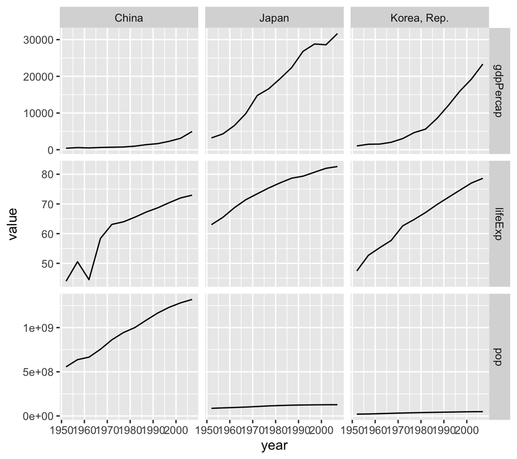

Take your time with this. Break the problem down into steps. Identify at least one step you’ll have to do, and then work backwards or forwards from there: What do I need to do in order to be able to do that step? What will I do once I have that step?

If you have time, here are further extensions you can try with this plot:

- Improve the axis labels, theme, and/or other features.
- Scale the variables so that the y-axis scales are nicer or more easily readable.
- What could you do to get the variables to be labeld in the plot as “Population”, “LifeExpectancy”, and “GDPperCapita”? (If you want, you can go further and try to make them “Population”, “Life Expectancy”, and “GDP per Capita” and even add units.)
- Try using `scales = "free"` in `facet_grid`. Does it do what you expect? Try replacing `facet_grid(..., scales = "free")` with `ggh4x::facet_grid2(..., scales = "free_y", independent = "y")`, i.e. use the `facet_grid2()` function from the `ggh4x` package, and see how you like it.